# Analysis

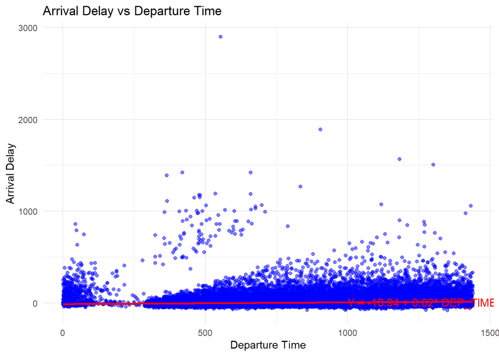

```r
#default priors in rstanarm are normal, normal, and exponential for the intercept, slope, and error respectively. The rstanarm framework also assumes independence of the priors [@bayesrulesbook].



#1 minute intervals for dep_time on x axis
predictions <- data.frame(
  DEP_TIME_MINS = seq(min(Delays_sample$DEP_TIME_MINS), max(Delays_sample$DEP_TIME_MINS), length.out = 1440)
)

predictions$fitted <- predict(model_stan, newdata = predictions)

#labelfor lm
intercept <- coef(model_stan)[1]
slope <- coef(model_stan)[2]
model_label <- paste("Y = ", round(intercept, 2), " + ", round(slope, 2), "* DEP_TIME", sep = "")


#plot for predictions
ggplot(Delays_sample, aes(x = DEP_TIME_MINS, y = ARR_DELAY)) +
  geom_point(color = "blue", alpha = 0.5) +
  geom_line(data = predictions, aes(x = DEP_TIME_MINS, y = fitted), color = "red", linewidth = 1) +
  labs(title = "Arrival Delay vs Departure Time",
       x = "Departure Time",
       y = "Arrival Delay") +
  theme_minimal() +
  annotate("text", x = 1000, y = 10, label = model_label,
           color = "red", size = 4, hjust = 0)
```

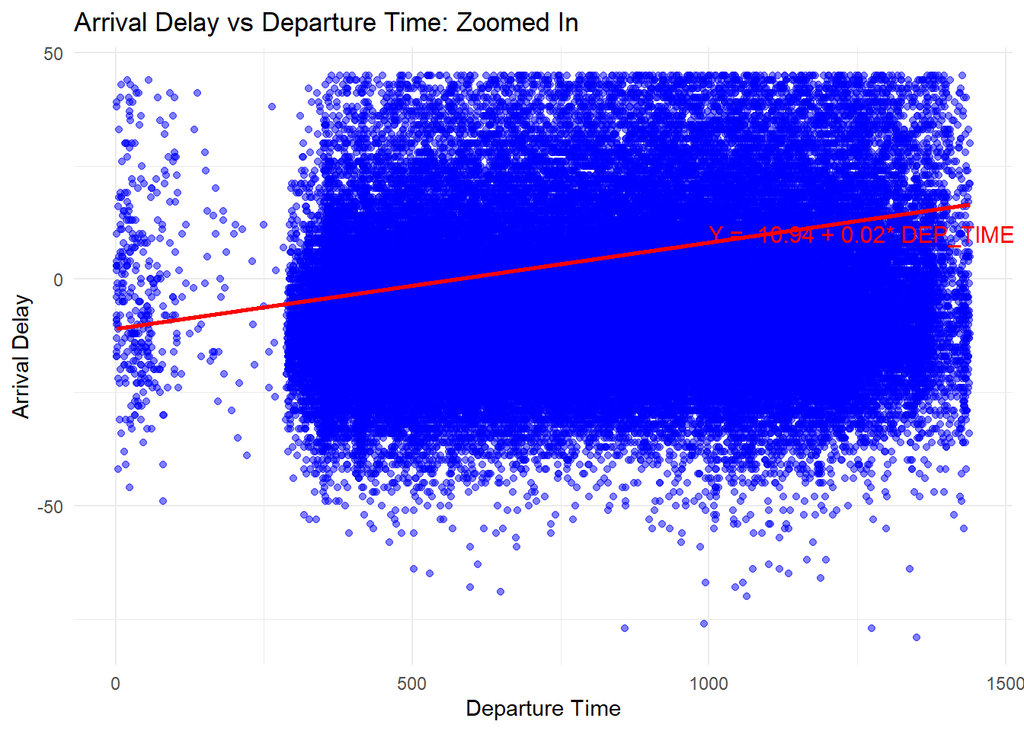

```r
ggplot(Delays_sample, aes(x = DEP_TIME_MINS, y = ARR_DELAY)) +
  geom_point(color = "blue", alpha = 0.5) +
  geom_line(data = predictions, aes(x = DEP_TIME_MINS, y = fitted), color = "red", linewidth = 1) +
  labs(title = "Arrival Delay vs Departure Time: Zoomed In ",
       x = "Departure Time",
       y = "Arrival Delay") +
  theme_minimal() +
  ylim(NA, 45) +
  annotate("text", x = 1000, y = 10, label = model_label,
           color = "red", size = 4, hjust = 0)
```

```r
summary(Delays_sample$DEP_TIME_MINS)
```

```
   Min. 1st Qu.  Median    Mean 3rd Qu.    Max.
    1.0   556.0   802.0   809.3  1058.0  1440.0
```

```r
summary(Delays_sample$ARR_DELAY)
```

```
    Min.  1st Qu.   Median     Mean  3rd Qu.     Max.
 -79.000  -15.000   -7.000    4.489    7.000 2900.000
```

## Specifying Priors

Since we are only using two data variables, arrival delay and departure time, the regression parameters will be $\beta_0$, $\beta_1$, and $\sigma$ for intercept, slope, and error As intercept and slope regression parameters can take any real value, we will use normal prior models (Johnson, Ott, and Dogucu 2022).

$$\begin{align*}
\beta_0 &\sim N(m_0, s^2_0)\\
\beta_1 &\sim N(m_1, s^2_1)
\end{align*}$$

where $m_0, s_0, m_1, \text{and } s_1$ are hyperparameters.

The standard deviation parameter must be positive, so we will use an exponential model (Johnson, Ott, and Dogucu 2022).

$$\sigma \sim \text{Exp}(l)$$

Due to the fact that the exponential model is a special case of the Gamma model, with $s = 1$, we can use the definitions of the mean and variance of the gamma model to to find that of the exponential model (Johnson, Ott, and Dogucu 2022).

$$\begin{align*}
E(\sigma) = \frac{1}{l} && \text{and} && SD(\sigma) = \frac{1}{l}
\end{align*}$$